# 0、Importing libraries

```python
import pandas as pd
import numpy as np
from pandas import DataFrame, Series
import seaborn as sns
import matplotlib.pyplot as plt
plt.style.use('fivethirtyeight')

%matplotlib inline
from warnings import filterwarnings
filterwarnings('ignore')
```

```python
path = r'C:\Users\selena\Downloads\North_American_Superstore.csv'
df = pd.read_csv(path, encoding="gbk")
```

## 0.1 Rename columns with spaces

```python
df.rename(columns = lambda x : x.replace(' ',''),inplace = True)  #  原始dataframe中列名中包含空格，需要进行替换
```

```python
df.shape
df.head()
```

|  | RowID | OrderID | OrderDate | ShipDate | ShipMode | CustomerID | CustomerName | Segment | Country | City | ... | PostalCode | Region | ProductID | Category | Sub-Category | ProductName | Sales | Quantity | Discount | Profit |
| --- | --- | --- | --- | --- | --- | --- | --- | --- | --- | --- | --- | --- | --- | --- | --- | --- | --- | --- | --- | --- | --- |
| 0 | 7981 | CA-2015-103800 | 2015/1/3 | 2015/1/7 | Standard Class | DP-13000 | Darren Powers | Consumer | United States | Houston | ... | 77095.0 | Central | OFF-PA-10000174 | Office Supplies | Paper | Message Book, Wirebound, Four 5 1/2" X 4" Form... | 16.448 | 2 | 0.2 | 5.5512 |
| 1 | 740 | CA-2015-112326 | 2015/1/4 | 2015/1/8 | Standard Class | PO-19195 | Phillina Ober | Home Office | United States | Naperville | ... | 60540.0 | Central | OFF-LA-10003223 | Office Supplies | Labels | Avery 508 | 11.784 | 3 | 0.2 | 4.2717 |
| 2 | 741 | CA-2015-112326 | 2015/1/4 | 2015/1/8 | Standard Class | PO-19195 | Phillina Ober | Home Office | United States | Naperville | ... | 60540.0 | Central | OFF-ST-10002743 | Office Supplies | Storage | SAFCO Boltless Steel Shelving | 272.736 | 3 | 0.2 | -64.7748 |
| 3 | 742 | CA-2015-112326 | 2015/1/4 | 2015/1/8 | Standard Class | PO-19195 | Phillina Ober | Home Office | United States | Naperville | ... | 60540.0 | Central | OFF-BI-10004094 | Office Supplies | Binders | GBC Standard Plastic Binding Systems Combs | 3.540 | 2 | 0.8 | -5.4870 |
| 4 | 1760 | CA-2015-141817 | 2015/1/5 | 2015/1/12 | Standard Class | MB-18085 | Mick Brown | Consumer | United States | Philadelphia | ... | 19143.0 | East | OFF-AR-10003478 | Office Supplies | Art | Avery Hi-Liter EverBold Pen Style Fluorescent ... | 19.536 | 3 | 0.2 | 4.8840 |

5 rows × 21 columns

# 一、Data Preparation

## 1.1 View overall data information

```python
df.shape
df.head()
df.describe()
df.info()
```

```
<class 'pandas.core.frame.DataFrame'>
RangeIndex: 9994 entries, 0 to 9993
Data columns (total 21 columns):
 #   Column        Non-Null Count  Dtype
---  ------        --------------  -----
 0   RowID         9994 non-null   int64
 1   OrderID       9994 non-null   object
 2   OrderDate     9994 non-null   object
 3   ShipDate      9994 non-null   object
 4   ShipMode      9994 non-null   object
 5   CustomerID    9994 non-null   object
 6   CustomerName  9994 non-null   object
 7   Segment       9994 non-null   object
 8   Country       9994 non-null   object
 9   City          9994 non-null   object
 10  State         9994 non-null   object
 11  PostalCode    9983 non-null   float64
 12  Region        9994 non-null   object
 13  ProductID     9994 non-null   object
 14  Category      9994 non-null   object
 15  Sub-Category  9994 non-null   object
 16  ProductName   9994 non-null   object
 17  Sales         9994 non-null   float64
 18  Quantity      9994 non-null   int64
 19  Discount      9994 non-null   float64
 20  Profit        9994 non-null   float64
dtypes: float64(4), int64(2), object(15)
memory usage: 1.6+ MB
```

## 1.2 Remove Duplicates

```python
df = df.drop_duplicates()
df.info()
```

```
<class 'pandas.core.frame.DataFrame'>
Int64Index: 9994 entries, 0 to 9993
Data columns (total 21 columns):
 #   Column        Non-Null Count  Dtype
---  ------        --------------  -----
 0   RowID         9994 non-null   int64
 1   OrderID       9994 non-null   object
 2   OrderDate     9994 non-null   object
 3   ShipDate      9994 non-null   object
 4   ShipMode      9994 non-null   object
 5   CustomerID    9994 non-null   object
 6   CustomerName  9994 non-null   object
 7   Segment       9994 non-null   object
 8   Country       9994 non-null   object
 9   City          9994 non-null   object
 10  State         9994 non-null   object
 11  PostalCode    9983 non-null   float64
 12  Region        9994 non-null   object
 13  ProductID     9994 non-null   object
 14  Category      9994 non-null   object
 15  Sub-Category  9994 non-null   object
 16  ProductName   9994 non-null   object
 17  Sales         9994 non-null   float64
 18  Quantity      9994 non-null   int64
 19  Discount      9994 non-null   float64
 20  Profit        9994 non-null   float64
dtypes: float64(4), int64(2), object(15)
memory usage: 1.7+ MB
```

## 1.3 Eliminate data with significantly abnormal values

```python
df.loc[df['Sales']<0].Sales.count()
df.loc[df['Sales']<0, ['OrderID', 'CustomerID', 'Sales']]
df = df.loc[(df['Sales']>0)&(df['Quantity']>0)]
```

## 1.4 Handling missing values

```python
df.isnull().sum()
```

```
RowID            0
OrderID          0
OrderDate        0
ShipDate         0
ShipMode         0
CustomerID       0
CustomerName     0
Segment          0
Country          0
City             0
State            0
PostalCode      11
Region           0
ProductID        0
Category         0
Sub-Category     0
ProductName      0
Sales            0
Quantity         0
Discount         0
Profit           0
dtype: int64
```

## 1.5 Convert the date from string to Timestamp

```python
df['OrderDate'] = pd.to_datetime(df['OrderDate'])
df.info()

# View the date range of the customer's order
print('The last order date：',df['OrderDate'].max())
print('The first order date：',df['OrderDate'].min())
```

```
<class 'pandas.core.frame.DataFrame'>
Int64Index: 9994 entries, 0 to 9993
Data columns (total 21 columns):
 #   Column        Non-Null Count  Dtype
---  ------        --------------  -----
 0   RowID         9994 non-null   int64
 1   OrderID       9994 non-null   object
 2   OrderDate     9994 non-null   datetime64[ns]
 3   ShipDate      9994 non-null   object
 4   ShipMode      9994 non-null   object
 5   CustomerID    9994 non-null   object
 6   CustomerName  9994 non-null   object
 7   Segment       9994 non-null   object
 8   Country       9994 non-null   object
 9   City          9994 non-null   object
 10  State         9994 non-null   object
 11  PostalCode    9983 non-null   float64
 12  Region        9994 non-null   object
 13  ProductID     9994 non-null   object
 14  Category      9994 non-null   object
 15  Sub-Category  9994 non-null   object
 16  ProductName   9994 non-null   object
 17  Sales         9994 non-null   float64
 18  Quantity      9994 non-null   int64
 19  Discount      9994 non-null   float64
 20  Profit        9994 non-null   float64
dtypes: datetime64[ns](1), float64(4), int64(2), object(14)
memory usage: 1.7+ MB
The last order date： 2018-12-30 00:00:00
The first order date： 2015-01-03 00:00:00
```

# 二、Analysis of customer value and customer profitability (based on improved RFM model)

A study by Arthur Hughes of the American Database Marketing Institute found that three important indicators were found in customer data analysis, namely: the most recent consumption (**Recency**) and the frequency of consumption (**Frequency**). , consumption amount (**Monetary** quota), they are important criteria to measure customer value. **RFM analysis** is an exploratory analysis method.

1. Classification criteria
   > - Important value customers (high, high, high): recent consumption time, high consumption frequency and high consumption amount, absolutely high-quality customers.
   > - Important customer retention (low, high, high): Recently, the consumption time has been long, but the consumption frequency and amount are high, indicating that this is a loyal customer who has not been here for a while, and needs to take the initiative to keep in touch with him.
   > - Important development customers (high, low, high): The recent consumption time is relatively recent, the consumption amount is high, but the frequency is not high, the loyalty is not high, and the potential users must focus on development.
   > - Important customer retention (low, low, high): The recent consumption time is far away, the consumption frequency is not high, but the consumption amount is high, which may be users who are about to lose or have been lost, and should be based on retention measures
2. The role of the model
   > - Identify high-quality customers, provide them with personalized communication and marketing services, and provide strong support for marketing decisions.
   > - Ability to measure customer value and customer profitability.
3. Disadvantages of the traditional model
   > - The Frequency used is the number of times the user places an order at all times, and there is an error in the cumulative effect of time
4. Improvements to the model
   > - Use the total number of orders placed / the number of years of user-generated transactions as the new Frequency

## 2.1 Get the Frequency of orders placed by different customers (CustomerID) at all times

```python
df_f = df.copy()
df_f.drop_duplicates(subset=['OrderID'],keep='first',inplace=True)  #  Combine the same order
# df_f.info()
df_freq = df_f.groupby('CustomerID',as_index=False).OrderID.count().rename(columns={'OrderID':'Frequency'})
df_freq.set_index('CustomerID',drop=True,inplace=True)
df_freq.head()
```

| CustomerID | Frequency |
| --- | --- |
| AA-10315 | 5 |
| AA-10375 | 9 |
| AA-10480 | 4 |
| AA-10645 | 6 |
| AB-10015 | 3 |

## 2.2 Get RFM---the order amount as Monetary, Profit and the number of days from the current time to the last order for different customers (CustomerID) as Recency

```python
df_group = df.groupby('CustomerID')
# lambda df : df.max() - df.min()
df_rm = df_group.agg({'Sales':'sum','OrderDate':'max','Profit':'sum'}).rename(columns={'Sales':'Monetary'})
df_rm['Recency'] = (pd.to_datetime('2019-01-01') - df_rm['OrderDate']).dt.days
df_rm.head()
df_rm = df_rm.drop('OrderDate',axis=1)
df_rm.head()
# df_rm.info()
```

| CustomerID | Monetary | Profit | Recency |
| --- | --- | --- | --- |
| AA-10315 | 5563.560 | -362.8825 | 186 |
| AA-10375 | 1056.390 | 277.3824 | 21 |
| AA-10480 | 1790.512 | 435.8274 | 261 |
| AA-10645 | 5086.935 | 857.8033 | 57 |
| AB-10015 | 886.156 | 129.3465 | 417 |

## 2.3 Get the average annual frequency of orders placed by different customers (CustomerID) within the years of their purchases

```python
DiffYears = df_group.agg({'OrderDate':(lambda df : df.dt.year.max() - df.dt.year.min()+1)}).rename(
    columns={'OrderDate':'DiffYears'}).DiffYears
DiffYears.head()
df_freq.Frequency=df_freq.Frequency/DiffYears
df_freq.head()
```

| CustomerID | Frequency |
| --- | --- |
| AA-10315 | 1.25 |
| AA-10375 | 2.25 |
| AA-10480 | 1.00 |
| AA-10645 | 1.50 |
| AB-10015 | 1.00 |

## 2.4 Merge the above Recency, Frequency and Monetary by CustomerID (Profit is used for profit analysis)

```python
df_rfm = df_rm.merge(df_freq,on='CustomerID')
df_rfm.info()
df_rfm.head()
df_rfm.describe()
```

```
<class 'pandas.core.frame.DataFrame'>
Index: 793 entries, AA-10315 to ZD-21925
Data columns (total 4 columns):
 #   Column     Non-Null Count  Dtype
---  ------     --------------  -----
 0   Monetary   793 non-null    float64
 1   Profit     793 non-null    float64
 2   Recency    793 non-null    int64
 3   Frequency  793 non-null    float64
dtypes: float64(3), int64(1)
memory usage: 31.0+ KB
```

|  | Monetary | Profit | Recency | Frequency |
| --- | --- | --- | --- | --- |
| count | 793.000000 | 793.000000 | 793.000000 | 793.000000 |
| mean | 2896.848500 | 361.156396 | 148.773014 | 1.818306 |
| std | 2628.670117 | 894.261812 | 186.111367 | 0.673193 |
| min | 4.833000 | -6626.389500 | 2.000000 | 0.500000 |
| 25% | 1146.050000 | 36.613100 | 32.000000 | 1.250000 |
| 50% | 2256.394000 | 227.833800 | 77.000000 | 1.750000 |
| 75% | 3785.276000 | 560.007800 | 185.000000 | 2.250000 |
| max | 25043.050000 | 8981.323900 | 1167.000000 | 5.000000 |

## 2.5 Divide each customer by type based on the median

```python
r_med = df_rfm['Recency'].median()
f_med = df_rfm['Frequency'].median()
m_med = df_rfm['Monetary'].median()
r_med,f_med,m_med
```

```
(77.0, 1.75, 2256.394)
```

```python
# Create the function to classify different customer types
def customer_type_func(frame):
    customer_type_list = []
    for i in range(len(frame)):
        if frame.iloc[i,2]<=r_med and frame.iloc[i,3]>=f_med and frame.iloc[i,0]>=m_med:
            customer_type_list.append('Champions')
        elif  frame.iloc[i,2]<=r_med and frame.iloc[i,3]<f_med and frame.iloc[i,0]>=m_med:
            customer_type_list.append('Big Spenders')
        elif  frame.iloc[i,2]>r_med and frame.iloc[i,3]>=f_med and frame.iloc[i,0]>=m_med:
            customer_type_list.append('Customers Needing Attention')
        elif  frame.iloc[i,2]>r_med and frame.iloc[i,3]<f_med and frame.iloc[i,0]>=m_med:
            customer_type_list.append('Can not lose them')
        else:
            customer_type_list.append('Ordinary Customer')
    frame['CustomerType'] = customer_type_list
customer_type_func(df_rfm)
```

## 2.6 Analyze the overall profitability of different types of customers

- The total number of customers acquired by different types and the number of customers with profit > 0

```python
df_rfm['ProfitType'] = (df_rfm.Profit>0)
df_ProfitCustNum= df_rfm.groupby(['CustomerType','ProfitType']).size().reset_index(name='ProfitCustNum')
df_ProfitCustNum
```

|  | CustomerType | ProfitType | ProfitCustNum |
| --- | --- | --- | --- |
| 0 | Big Spenders | False | 9 |
| 1 | Big Spenders | True | 42 |
| 2 | Can not lose them | False | 11 |
| 3 | Can not lose them | True | 41 |
| 4 | Champions | False | 32 |
| 5 | Champions | True | 147 |
| 6 | Customers Needing Attention | False | 16 |
| 7 | Customers Needing Attention | True | 99 |
| 8 | Ordinary Customer | False | 87 |
| 9 | Ordinary Customer | True | 309 |

```python
df_ProfitCustNum = df_ProfitCustNum[df_ProfitCustNum.ProfitType==True]
df_ProfitCustNum
```

|  | CustomerType | ProfitType | ProfitCustNum |
| --- | --- | --- | --- |
| 1 | Big Spenders | True | 42 |
| 3 | Can not lose them | True | 41 |
| 5 | Champions | True | 147 |
| 7 | Customers Needing Attention | True | 99 |
| 9 | Ordinary Customer | True | 309 |

```python
df_Customer_Num = df_rfm.groupby(['CustomerType']).size().reset_index(name='CustomerNum')
df_Customer_Num
```

|  | CustomerType | CustomerNum |
| --- | --- | --- |
| 0 | Big Spenders | 51 |
| 1 | Can not lose them | 52 |
| 2 | Champions | 179 |
| 3 | Customers Needing Attention | 115 |
| 4 | Ordinary Customer | 396 |

- The total number of customers acquired by different types and the percentage of customers that profit > 0

```python
df_Customer_Num['ProfitCustRate'] = df_ProfitCustNum.ProfitCustNum.values/df_Customer_Num.CustomerNum
df_Customer_Num.head()
```

|  | CustomerType | CustomerNum | ProfitCustRate |
| --- | --- | --- | --- |
| 0 | Big Spenders | 51 | 0.823529 |
| 1 | Can not lose them | 52 | 0.788462 |
| 2 | Champions | 179 | 0.821229 |
| 3 | Customers Needing Attention | 115 | 0.860870 |
| 4 | Ordinary Customer | 396 | 0.780303 |

- Order amount and profit of different types of customers and their proportion in total amount and total profit

```python
df_Profit= df_rfm.groupby(['CustomerType']).Profit.sum().reset_index(name='Profit')
df_Profit
```

|  | CustomerType | Profit |
| --- | --- | --- |
| 0 | Big Spenders | 30303.5112 |
| 1 | Can not lose them | 29365.3520 |
| 2 | Champions | 95770.4661 |
| 3 | Customers Needing Attention | 85341.7552 |
| 4 | Ordinary Customer | 45615.9372 |

```python
df_Monetary = df_rfm.groupby('CustomerType').Monetary.sum().reset_index(name='Monetary')
df_Monetary['ProfitRate'] = df_Profit.Profit/df_Monetary.Monetary
df_Monetary['Profit'] = df_Profit.Profit
df_Monetary['MonetaryPerCust'] = df_Monetary.Monetary/df_Customer_Num.CustomerNum
df_Monetary['ProfitPerCust'] = df_Monetary.Profit/df_Customer_Num.CustomerNum
df_Monetary
```

|  | CustomerType | Monetary | ProfitRate | Profit | MonetaryPerCust | ProfitPerCust |
| --- | --- | --- | --- | --- | --- | --- |
| 0 | Big Spenders | 236080.1130 | 0.128361 | 30303.5112 | 4629.021824 | 594.186494 |
| 1 | Can not lose them | 229137.1534 | 0.128156 | 29365.3520 | 4406.483719 | 564.718308 |
| 2 | Champions | 816862.0390 | 0.117242 | 95770.4661 | 4563.475078 | 535.030537 |
| 3 | Customers Needing Attention | 559257.1580 | 0.152598 | 85341.7552 | 4863.105722 | 742.102219 |
| 4 | Ordinary Customer | 455864.3969 | 0.100065 | 45615.9372 | 1151.172719 | 115.191761 |

## 2.7 Customer RFM model classification and profit-making visualization

- Distribution of R/F/M for different types of customers

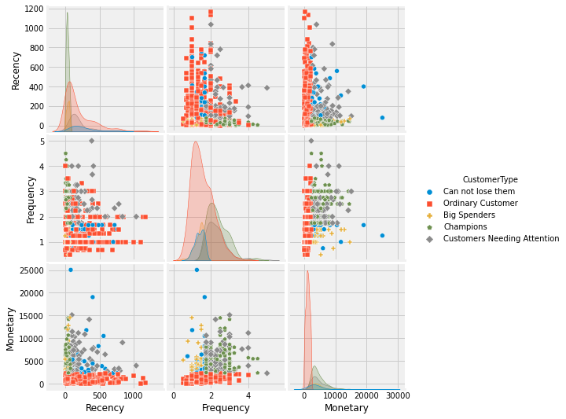

```python
sns.pairplot(df_rfm,hue='CustomerType', x_vars=["Recency", "Frequency", "Monetary"],
    y_vars=["Recency", "Frequency", "Monetary"], markers=["o", "s", "P","p","D"])
```

- Distribution of the number of different types of customers

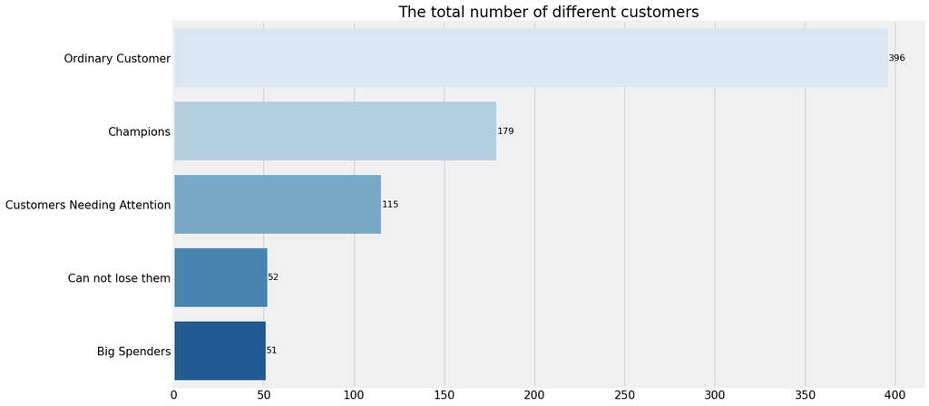

```python
fig1 = plt.figure(1,figsize=(16,9),dpi=100)
ax1_1 = fig1.add_subplot(111)
sns.countplot(y='CustomerType',order=df_rfm['CustomerType'].value_counts(ascending=False).index,data=df_rfm,palette='Blues')
ax1_1.tick_params(labelsize=15)
ax1_1.set_title('The total number of different customers',fontsize=20)
ax1_1.set_xlabel('')
ax1_1.set_ylabel('')
num_by_type=list(df_rfm.groupby('CustomerType').size())
num_by_type=sorted(num_by_type,reverse=True)
for x,y in enumerate(num_by_type):
    ax1_1.text(y+0.2,x,'%s' %y,va='center',size=12)
```

- Profitability analysis of different types of customers

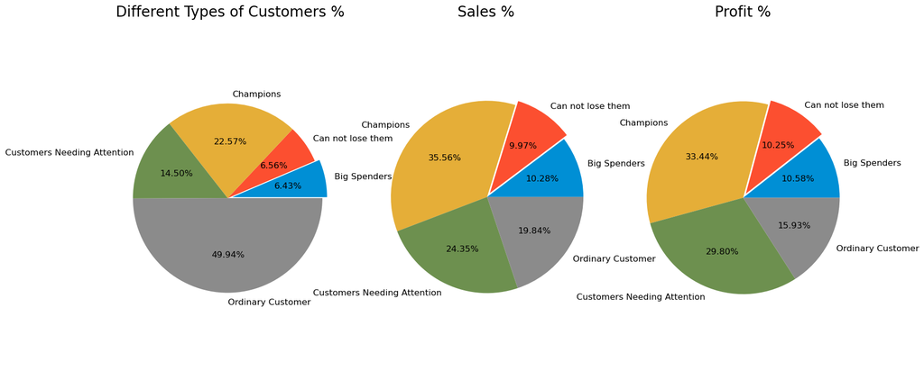

```python
fig2 = plt.figure(2,figsize=(16,9),dpi=100)

ax2_1 = fig2.add_subplot(131)
labels=df_rfm.groupby('CustomerType').CustomerType.size().index
customer_num=df_rfm.groupby('CustomerType').CustomerType.size()
explode=[0.05,0,0,0,0]
ax2_1.pie(customer_num,explode=explode,labels=labels,textprops={'fontsize':12},shadow=False,autopct='%.2f%%')
ax2_1.axis('equal')
ax2_1.set_title('Different Types of Customers %',fontsize=20)

ax2_2 = fig2.add_subplot(132)
Monetary_sum=df_rfm.groupby('CustomerType').Monetary.sum()
explode=[0,0.05,0,0,0]
ax2_2.pie(Monetary_sum,explode=explode,labels=labels,textprops={'fontsize':12},shadow=False,autopct='%.2f%%')
ax2_2.axis('equal')
ax2_2.set_title('Sales %',fontsize=20)

ax2_3 = fig2.add_subplot(133)
Porfit_sum=df_rfm.groupby('CustomerType').Profit.sum()
explode=[0,0.05,0,0,0]
ax2_3.pie(Porfit_sum,explode=explode,labels=labels,textprops={'fontsize':12},shadow=False,autopct='%.2f%%')
ax2_3.axis('equal')
ax2_3.set_title('Profit %',fontsize=20)
```

# 三、Cohort Analysis

**Cohort Analysis** (Cohort Analysis, also known as group analysis), its main purpose is to analyze the changes in the behavior of similar groups over time (such as the repurchase of products, the use of products/services, etc.)

1. Mainly include two forms
> - Initial behavior: such as "first useage of the app", "successful registration" or "first purchase behavior", etc.;
> - Retention behavior: It can be any behavior of the user, such as purchasing, using App, sharing, etc.;
1. Analysis process
> - By grouping users according to the occurrence time of the initial behavior (to get the cohort), and then counting the occurrence frequency of the retained behavior in different time periods after the initial behavior time.
1. Function and application
> - Cohort analysis allows us to observe the behavior of customers at different stages of the life cycle. Applicable to the data indicators we care about, such as revenue, user retention/churn, sharing and communication.

## 3.1 Each year is divided into two terms as a cycle

```python
df1 = df_f.copy()
# Define time nodes separately as the start of each cycle
time_nodes = pd.to_datetime(['2014-12-31','2015-06-30','2015-12-31','2016-06-30','2016-12-31','2017-06-30','2017-12-31','2018-06-30','2018-12-31'])
# Each cycle is identified by 2015H1, for example, 2015H1 means the first half of 2015 (the first Half year)
label = ['2015H1','2015H2','2016H1','2016H2','2017H1','2017H2','2018H1','2018H2']
# Save the customer ID corresponding to different orders in each cycle, there may be duplicate values
customer_list = []
# Save the customer ID of the order placed in each cycle, no duplicate value
u_customer_list = []
# df1.head()
df1.info()
```

```
<class 'pandas.core.frame.DataFrame'>
Int64Index: 5009 entries, 0 to 9993
Data columns (total 21 columns):
 #   Column        Non-Null Count  Dtype
---  ------        --------------  -----
 0   RowID         5009 non-null   int64
 1   OrderID       5009 non-null   object
 2   OrderDate     5009 non-null   datetime64[ns]
 3   ShipDate      5009 non-null   object
 4   ShipMode      5009 non-null   object
 5   CustomerID    5009 non-null   object
 6   CustomerName  5009 non-null   object
 7   Segment       5009 non-null   object
 8   Country       5009 non-null   object
 9   City          5009 non-null   object
 10  State         5009 non-null   object
 11  PostalCode    5003 non-null   float64
 12  Region        5009 non-null   object
 13  ProductID     5009 non-null   object
 14  Category      5009 non-null   object
 15  Sub-Category  5009 non-null   object
 16  ProductName   5009 non-null   object
 17  Sales         5009 non-null   float64
 18  Quantity      5009 non-null   int64
 19  Discount      5009 non-null   float64
 20  Profit        5009 non-null   float64
dtypes: datetime64[ns](1), float64(4), int64(2), object(14)
memory usage: 860.9+ KB
```

## 3.2 Get customer IDs of orders placed in different cycles

```python
for i in range(8):
    customer_half_year = df1.loc[(df1.OrderDate>time_nodes[i])&(df1.OrderDate<=time_nodes[i+1]),:].CustomerID
    u_customer_half_year = list(set(customer_half_year))
    print(label[i]+'The number of customers who place an order before deduplication', len(customer_half_year))
    print(label[i]+'The number of customers who place an order after deduplication', len(u_customer_half_year))
    customer_list.extend(customer_half_year)
    u_customer_list.append(u_customer_half_year)
# print(len(customer_list))
```

```
2015H1The number of customers who place an order before deduplication 332
2015H1The number of customers who place an order after deduplication 281
2015H2The number of customers who place an order before deduplication 637
2015H2The number of customers who place an order after deduplication 456
2016H1The number of customers who place an order before deduplication 358
2016H1The number of customers who place an order after deduplication 293
2016H2The number of customers who place an order before deduplication 680
2016H2The number of customers who place an order after deduplication 455
2017H1The number of customers who place an order before deduplication 473
2017H1The number of customers who place an order after deduplication 352
2017H2The number of customers who place an order before deduplication 842
2017H2The number of customers who place an order after deduplication 517
2018H1The number of customers who place an order before deduplication 607
2018H1The number of customers who place an order after deduplication 436
2018H2The number of customers who place an order before deduplication 1080
2018H2The number of customers who place an order after deduplication 594
```

## 3.3 cohort analysis

- Due to the data set, the IDs of all the old customers in history cannot be determined, so an assumption is made: the customers who placed orders in the first half of 2015 are old customers, new customers are counted from the second half of 2015, and customers are counted from the first half of 2016. Repurchase rate/retention rate

```python
for i, customer_list_half_year in enumerate(u_customer_list):
    if i>0 and i<7:
        last_list = []  #  Save customer ID for all past time (de-duplication)
        retain_list = []  #  Save the number of customers who repurchase every six months in the future
        for j in range(0,i):
            last_list.extend(u_customer_list[j])
        last_list = list(set(last_list))
        new_list = [cust for cust in customer_list_half_year if cust not in last_list]  #  Save the new customer ID in current cycle
        for k in range(i+1,8):
            retain_list.append(len([cust for cust in u_customer_list[k] if cust in new_list]))
        print(label[i]+'The number of new customers is', len(new_list), 'The retention rate is',[round(i/len(new_list), 3) for i in retain_list])
```

```
2015H2The number of new customers is 314 The retention rate is [0.373, 0.589, 0.452, 0.659, 0.545, 0.752]
2016H1The number of new customers is 68 The retention rate is [0.544, 0.426, 0.676, 0.588, 0.735]
2016H2The number of new customers is 68 The retention rate is [0.324, 0.603, 0.574, 0.721]
2017H1The number of new customers is 36 The retention rate is [0.667, 0.583, 0.861]
2017H2The number of new customers is 15 The retention rate is [0.4, 0.8]
2018H1The number of new customers is 5 The retention rate is [0.6]
```